# HW2

Author

Yuanjie Xu

link to my GitHub repository: https://github.com/Atrader124/STATS-506

## Problem 1 - Dice Game

1. Version 1: Implement this game using a loop over the die rolls.

```r
dice_v1 <- function(x) {
  result <- -2 * x # the cost
  for(i in 1:x) {
    dice <- sample(1:6, 1)
    if(dice %% 2 == 0) {
      # check if this roll wins
      result <- result + dice
      # if wins, win the amount on the roll
    }
  }
  return(result)
}
```

Version 2: Implement this game using built-in R vectorized functions.

```r
dice_v2 <- function(x) {
  dice <- sample(1:6, x, replace = TRUE)
  win <- dice[dice %% 2 == 0]
  # the total amount wins
  result <- sum(win) - 2 * x
  return(result)
}
```

Version 3: Implement this by collapsing the die rolls into a single table().

```r
dice_v3 <- function(x) {
  dice <- sample(1:6, x, replace = TRUE)
  stats <- table(dice)
  win <- sum((as.numeric(names(stats)) %% 2 == 0) * as.numeric(names(stats)) * as.integer(stats))
  # the total amount wins
  result = win - 2 * x
  return(result)
}
```

Version 4: Implement this game by using one of the “apply” functions.

```r
dice_v4 <- function(x) {
  dice <- sample(1:6, x, replace = TRUE)
  win <- sapply(dice, function(y) if(y %% 2 == 0) return(y) else return(0))
  result <- sum(win) - 2 * x
  return(result)
}
```

2. Demonstrate that all versions work. Do so by running each a few times, once with an input a 3, and once with an input of 3000.

```r
cat("Version 1 with input 3:", dice_v1(3), "\n")
```

```
Version 1 with input 3: -4
```

```r
cat("Version 1 with input 3000:", dice_v1(3000), "\n")
```

```
Version 1 with input 3000: 96
```

```r
cat("Version 2 with input 3:", dice_v2(3), "\n")
```

```
Version 2 with input 3: -6
```

```r
cat("Version 2 with input 3000:", dice_v2(3000), "\n")
```

```
Version 2 with input 3000: 98
```

```r
cat("Version 3 with input 3:", dice_v1(3), "\n")
```

```
Version 3 with input 3: -2
```

```r
cat("Version 3 with input 3000:", dice_v1(3000), "\n")
```

```
Version 3 with input 3000: -258
```

```r
cat("Version 4 with input 3:", dice_v1(3), "\n")
```

```
Version 4 with input 3: 0
```

```r
cat("Version 4 with input 3000:", dice_v1(3000), "\n")
```

```
Version 4 with input 3000: 38
```

3. Demonstrate that the four versions give the same result. Test with inputs 3 and 3000. (You may need to add a way to control the randomization.)

```r
set.seed(123)
cat("Version 1 with input 3:", dice_v1(3), "\n")
```

```
Version 1 with input 3: 0
```

```r
set.seed(123)
cat("Version 1 with input 3000:", dice_v1(3000), "\n")
```

```
Version 1 with input 3000: -102
```

```r
set.seed(123)
cat("Version 2 with input 3:", dice_v2(3), "\n")
```

```
Version 2 with input 3: 0
```

```r
set.seed(123)
cat("Version 2 with input 3000:", dice_v2(3000), "\n")
```

```
Version 2 with input 3000: -102
```

```r
set.seed(123)
cat("Version 3 with input 3:", dice_v3(3), "\n")
```

```
Version 3 with input 3: 0
```

```r
set.seed(123)
cat("Version 3 with input 3000:", dice_v3(3000), "\n")
```

```
Version 3 with input 3000: -102
```

```r
set.seed(123)
cat("Version 4 with input 3:", dice_v4(3), "\n")
```

```
Version 4 with input 3: 0
```

```r
set.seed(123)
cat("Version 4 with input 3000:", dice_v4(3000), "\n\n")
```

```
Version 4 with input 3000: -102
```

4. Use the microbenchmark package to clearly demonstrate the speed of the implementations. Compare performance with a low input (100) and a large input (10000). Discuss the results

```r
library(microbenchmark)
set.seed(123)
speed_100 <- microbenchmark(
  v1 = dice_v1(100),
  v2 = dice_v2(100),
  v3 = dice_v3(100),
  v4 = dice_v4(100),
  times = 100
)
# demonstrate speed when input = 100
set.seed(123)
speed_10000 <- microbenchmark(
  v1 = dice_v1(10000),
  v2 = dice_v2(10000),
  v3 = dice_v3(10000),
  v4 = dice_v4(10000),
  times = 100
)
# demonstrate speed when input = 10000
```

```r
print(speed_100)
```

```
Unit: microseconds
 expr   min    lq    mean median     uq    max neval
   v1 374.3 437.1 530.886 466.50 508.20 5543.3   100
   v2  11.2  12.5  18.246  13.45  15.35  106.0   100
   v3  69.9  78.6  97.843  88.55 104.90  194.8   100
   v4  71.3  76.7  91.339  82.85  95.30  209.8   100
```

```r
print(speed_10000)
```

```
Unit: microseconds
 expr     min       lq      mean   median       uq     max neval
   v1 42306.1 44061.00 46881.382 45491.25 47773.55 76957.4   100
   v2   570.5   594.00   630.310   619.30   652.75   790.4   100
   v3   799.0   923.10  1007.059   980.65  1078.95  1611.5   100
   v4  5876.5  6297.55  7166.957  6530.70  7259.80 12918.5   100
```

The microbenchmark function from the microbenchmark package can calculate the code run time. So we can compare the speed between different R codes. This function enables us to find the fastest method to achieve functionality.

For a large input (10000):

5. Do you think this is a fair game? Defend your decision with evidence based upon a Monte Carlo simulation.

```r
M_C_simulation <- function(X) {
  results <- numeric(X)
  for(i in 1:X) {
    results[X] <- dice_v2(1000)
    # put X results in results
  }
  final_mean <- mean(results)
  return(final_mean)
}

X <- 10000
final_mean <- M_C_simulation(X)
print(final_mean)
```

```
[1] 0.013
```

```r
if (abs(final_mean) <= 1e-6) {
  # find out whether final_mean is close enough to zero
  print("It is a fair game.")
} else {
  print("It is not a fair game.")
}
```

```
[1] "It is not a fair game."
```

## Problem 2 - Linear Regression

1. The names of the variables in this data are way too long. Rename the columns of the data to more reasonable lengths.

```r
df <- read.csv("C:/Users/user/Desktop/cars.csv",header = TRUE)
names(df) <- c("Height","Length","Width","Driveline","EngineType","Hybrid","ForwardGears","Transmission","Citympg","FuelType","Highwaympg","Classification","ID","Make","ModelYear","Year","Horsepower","Torque")
```

2. Restrict the data to cars whose Fuel Type is “Gasoline”.

```r
df_gasoline <- subset(df, FuelType == "Gasoline")
```

3. Fit a linear regression model predicting MPG on the highway.

```r
model <- lm(Highwaympg ~ Horsepower + Torque + Length + Width + Height +  as.factor(Year), data=df_gasoline)
summary(model)
```

```
Call:
lm(formula = Highwaympg ~ Horsepower + Torque + Length + Width +
    Height + as.factor(Year), data = df_gasoline)

Residuals:
    Min      1Q  Median      3Q     Max
-10.824  -2.550  -0.452   2.372 202.639

Coefficients:
                      Estimate Std. Error t value Pr(>|t|)
(Intercept)         32.2926630  0.7225982  44.690  < 2e-16 ***
Horsepower           0.0163556  0.0022772   7.182 7.96e-13 ***
Torque              -0.0507425  0.0022030 -23.034  < 2e-16 ***
Length               0.0017290  0.0008836   1.957   0.0504 .
Width               -0.0003343  0.0009045  -0.370   0.7117
Height               0.0099079  0.0011267   8.794  < 2e-16 ***
as.factor(Year)2010 -0.4539681  0.6768246  -0.671   0.5024
as.factor(Year)2011  0.1711016  0.6757043   0.253   0.8001
as.factor(Year)2012  1.3029279  0.6810076   1.913   0.0558 .
---
Signif. codes:  0 '***' 0.001 '**' 0.01 '*' 0.05 '.' 0.1 ' ' 1

Residual standard error: 4.602 on 4582 degrees of freedom
Multiple R-squared:  0.4192,    Adjusted R-squared:  0.4182
F-statistic: 413.3 on 8 and 4582 DF,  p-value: < 2.2e-16
```

The coefficient for Horsepower is 0.01635. The coefficient for Horsepower represents if one unit Horsepower increases, how many units will be changed in Highway MPG on average, holding all other control variables constant. So if Horsepower increases 1 unit, Highway.MPG will increase 0.01635 units on average, holding all other control variables constant. According to the t-test, this effect is statistically significant.

4. It seems reasonable that there may be an interaction between horsepower and torque. Refit the model (with lm) and generate an interaction plot, showing how the relationship between horsepower and MPG changes as torque changes. Choose reasonable values of horsepower, and show lines for three different reasonable values of torque.

```r
model_interaction <- lm(Highwaympg ~  Horsepower*Torque + Length + Width + Height + as.factor(Year), data=df_gasoline)
summary(model_interaction)
```

```
Call:
lm(formula = Highwaympg ~ Horsepower * Torque + Length + Width +
    Height + as.factor(Year), data = df_gasoline)

Residuals:
    Min      1Q  Median      3Q     Max
-11.109  -2.313  -0.258   2.062 203.540

Coefficients:
                      Estimate Std. Error t value Pr(>|t|)
(Intercept)          4.219e+01  7.930e-01  53.199  < 2e-16 ***
Horsepower          -1.666e-02  2.539e-03  -6.563 5.84e-11 ***
Torque              -8.606e-02  2.533e-03 -33.972  < 2e-16 ***
Length               1.777e-03  8.318e-04   2.136   0.0327 *
Width               -1.169e-03  8.521e-04  -1.372   0.1700
Height               6.560e-03  1.070e-03   6.133 9.32e-10 ***
as.factor(Year)2010 -5.628e-01  6.372e-01  -0.883   0.3771
as.factor(Year)2011  7.254e-02  6.361e-01   0.114   0.9092
as.factor(Year)2012  1.197e+00  6.411e-01   1.867   0.0619 .
Horsepower:Torque    1.124e-04  4.628e-06  24.276  < 2e-16 ***
---
Signif. codes:  0 '***' 0.001 '**' 0.01 '*' 0.05 '.' 0.1 ' ' 1

Residual standard error: 4.333 on 4581 degrees of freedom
Multiple R-squared:  0.4854,    Adjusted R-squared:  0.4844
F-statistic: 480.1 on 9 and 4581 DF,  p-value: < 2.2e-16
```

```r
print("Horsepower")
```

```
[1] "Horsepower"
```

```r
summary(df_gasoline$Horsepower)
```

```
   Min. 1st Qu.  Median    Mean 3rd Qu.    Max.
  100.0   185.0   263.0   267.5   317.0   638.0
```

```r
print("Torque")
```

```
[1] "Torque"
```

```r
summary(df_gasoline$Torque)
```

```
   Min. 1st Qu.  Median    Mean 3rd Qu.    Max.
   98.0   177.0   257.0   267.2   332.0   774.0
```

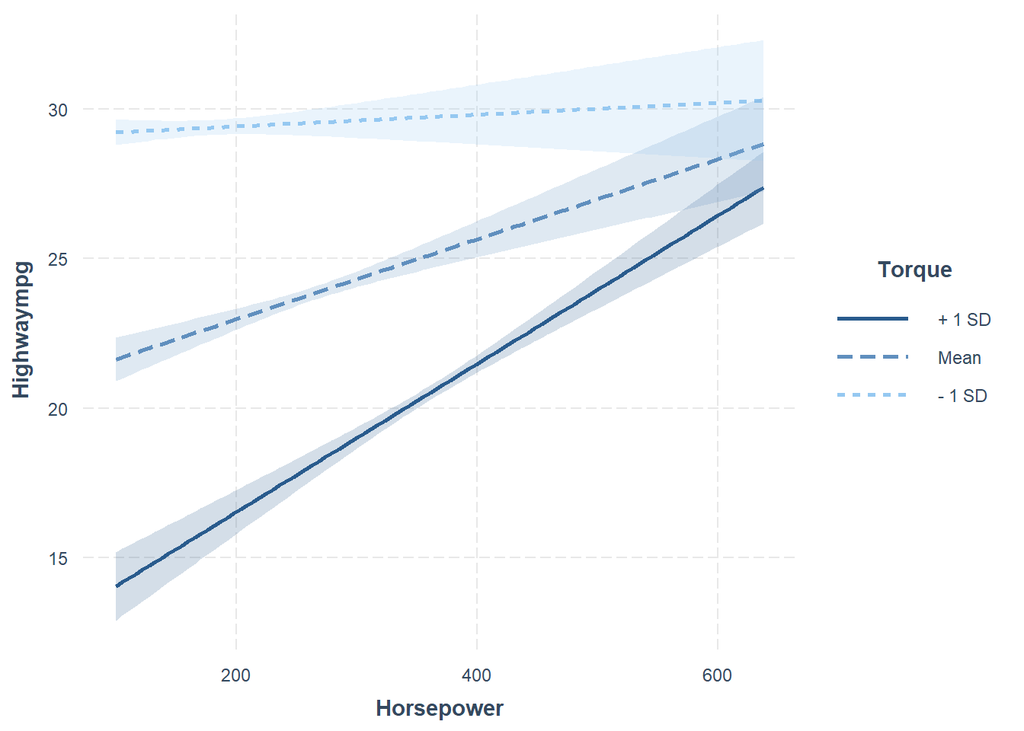

```r
library(interactions)
interact_plot(model_interaction, pred = Horsepower, modx = Torque, interval = TRUE, at = list(Year = 2011), data = df_gasoline)
```

5. Calculate beta from d. manually (without using lm) by first creating a proper design matrix, then using matrix algebra to estimate beta. Confirm that you get the same result as lm did prior.

```r
X <- model.matrix(~ Horsepower*Torque + Length + Width + Height + as.factor(Year), data=df_gasoline)
y <- df_gasoline$Highwaympg
beta_direct <- solve(t(X) %*% X) %*% t(X) %*% y
# manually calculate beta
beta_lm <- coef(model_interaction)
# use lm to calculate beta
print("beta_direct")
```

```
[1] "beta_direct"
```

```r
print(beta_direct)
```

```
                             [,1]
(Intercept)         42.1879478687
Horsepower          -0.0166633227
Torque              -0.0860592704
Length               0.0017767232
Width               -0.0011694485
Height               0.0065603903
as.factor(Year)2010 -0.5627857770
as.factor(Year)2011  0.0725356431
as.factor(Year)2012  1.1970329986
Horsepower:Torque    0.0001123567
```

```r
print("beta_lm")
```

```
[1] "beta_lm"
```

```r
print(beta_lm)
```

```
        (Intercept)          Horsepower              Torque              Length
      42.1879478687       -0.0166633227       -0.0860592704        0.0017767232
              Width              Height as.factor(Year)2010 as.factor(Year)2011
      -0.0011694485        0.0065603903       -0.5627857770        0.0725356431
as.factor(Year)2012   Horsepower:Torque
       1.1970329986        0.0001123567
```

```stata
. cd C:\Users\user\Desktop
C:\Users\user\Desktop

.
. clear all

.
. import delimited "cars.csv", encoding(UTF-8)
(18 vars, 5,076 obs)

.
. rename dimensionsheight height

.
. rename dimensionslength length

.
. rename dimensionswidth width

.
. rename engineinformationdriveline driveline

.
. rename engineinformationenginetype enginetype

.
. rename engineinformationhybrid hybrid

.
. rename engineinformationnumberofforward numberofforward

.
. rename engineinformationtransmission transmission

.
. rename fuelinformationcitympg citympg

.
. rename fuelinformationfueltype fueltype

.
. rename fuelinformationhighwaympg highwaympg

.
. rename identificationclassification classification

.
. rename identificationid id

.
. rename identificationmake make

.
. rename identificationmodelyear modelyear

.
. rename identificationyear year

.
. rename engineinformationenginestatistic horsepower

.
. rename v18 torque

.
. keep if fueltype == "Gasoline"
(485 observations deleted)

.
. regress highwaympg horsepower torque height length width i.year

      Source |       SS           df       MS      Number of obs   =     4,591
-------------+----------------------------------   F(8, 4582)      =    413.35
       Model |  70043.6695         8  8755.45869   Prob > F        =    0.0000
    Residual |   97055.298     4,582  21.1818634   R-squared       =    0.4192
-------------+----------------------------------   Adj R-squared   =    0.4182
       Total |  167098.968     4,590  36.4050038   Root MSE        =    4.6024

------------------------------------------------------------------------------
  highwaympg | Coefficient  Std. err.      t    P>|t|     [95% conf. interval]
-------------+----------------------------------------------------------------
  horsepower |   .0163556   .0022772     7.18   0.000     .0118913      .02082
      torque |  -.0507425    .002203   -23.03   0.000    -.0550614   -.0464236
      height |   .0099079   .0011267     8.79   0.000      .007699    .0121168
      length |    .001729   .0008836     1.96   0.050    -3.36e-06    .0034613
       width |  -.0003343   .0009045    -0.37   0.712    -.0021075    .0014388
             |
        year |
       2010  |  -.4539681   .6768246    -0.67   0.502     -1.78087    .8729342
       2011  |   .1711016   .6757043     0.25   0.800    -1.153604    1.495808
       2012  |   1.302928   .6810076     1.91   0.056    -.0321751    2.638031
             |
       _cons |   32.29266   .7225982    44.69   0.000     30.87602     33.7093
------------------------------------------------------------------------------

.
. regress highwaympg c.horsepower##c.torque c.length c.width c.height i.year

      Source |       SS           df       MS      Number of obs   =     4,591
-------------+----------------------------------   F(9, 4581)      =    480.07
       Model |  81105.8715         9  9011.76351   Prob > F        =    0.0000
    Residual |   85993.096     4,581  18.7716865   R-squared       =    0.4854
-------------+----------------------------------   Adj R-squared   =    0.4844
       Total |  167098.968     4,590  36.4050038   Root MSE        =    4.3326

---------------------------------------------------------------------------------------
           highwaympg | Coefficient  Std. err.      t    P>|t|     [95% conf. interval]
----------------------+----------------------------------------------------------------
           horsepower |  -.0166633   .0025388    -6.56   0.000    -.0216406    -.011686
               torque |  -.0860593   .0025333   -33.97   0.000    -.0910257   -.0810928
                      |
c.horsepower#c.torque |   .0001124   4.63e-06    24.28   0.000     .0001033    .0001214
                      |
               length |   .0017767   .0008318     2.14   0.033     .0001459    .0034075
                width |  -.0011694   .0008521    -1.37   0.170      -.00284    .0005011
               height |   .0065604   .0010696     6.13   0.000     .0044634    .0086573
                      |
                 year |
                2010  |  -.5627858   .6371716    -0.88   0.377    -1.811949    .6863777
                2011  |   .0725356   .6361142     0.11   0.909    -1.174555    1.319626
                2012  |   1.197033   .6411085     1.87   0.062    -.0598488    2.453915
                      |
                _cons |   42.18795   .7930274    53.20   0.000     40.63323    43.74266
---------------------------------------------------------------------------------------

.
. summarize(horsepower)

    Variable |        Obs        Mean    Std. dev.       Min        Max
-------------+---------------------------------------------------------
  horsepower |      4,591    267.4659    97.43199        100        638

.
. summarize(torque)

    Variable |        Obs        Mean    Std. dev.       Min        Max
-------------+---------------------------------------------------------
      torque |      4,591    267.2196    101.3269         98        774

. interactplot, reverse
invalid line in style file anglestyle-ninety:
*label "90 degrees"
invalid line in style file anglestyle-ninety:
*label "90 degrees"

.
```